# Exercised Option Exaination

```r
override<-read.delim(file="https://raw.githubusercontent.com/CSISdefense/Lookup-Tables/master/contract/CSIS_contract_inspection.csv", sep=",")
inspect10x<-left_join(inspect10x,override,by="CSIScontractID")
# if(any(is.na(inspect10x$CSIS_inspection))) stop(paste("Contract without CSIS_inspection label:",
#                                                 paste((unique(inspect10x$CSIScontractID[is.na(inspect10x$CSIS_inspection)])),
#                                                       collapse=", ")))


knitr::kable(inspect10x%>% group_by(CSIScontractID) %>% dplyr::select(CSIScontractID,
                                         Base,
                                         SteadyScopeOptionGrowthAlone,
                                         SteadyScopeOptionGrowthMixed,
                                         SteadyScopeOptionRescision,
                                         ChangeOrderOptionModification,
                                         EndingOptionModification,
                                         OtherOptionModification,
                                         # Action_Obligation,
                                         # Deobligations
                                         CSIS_inspection
                                         ),format.args = list(big.mark=","))
```

| CSIScontractID | Base | SteadyScopeOptionGrowthAlone | SteadyScopeOptionGrowthMixed | SteadyScopeOptionRescision | ChangeOrderOptionModification | EndingOptionModification | OtherOptionModification | CSIS_inspection |
| --- | --- | --- | --- | --- | --- | --- | --- | --- |
| 10,060,591 | 200,000.00 | 3,990,652.50 | 21,857.56 | -83,234.43 | 0.00 | -23,680.00 | 0 | Passed Examination |
| 24,596,370 | 200,613.00 | 2,545,263.00 | 0.00 | 0.00 | 0.00 | 0.00 | 0 | NA |
| 2,893,470 | 79,715.00 | 1,015,140.00 | 91,394.11 | -20,941.14 | 0.00 | 0.00 | 0 | Error: Corrected Administratively |
| 60,378,093 | 16,642.50 | 190,779.79 | 0.00 | -1,200.00 | 0.00 | 0.00 | 0 | Passed Examination |
| 18,192,191 | 1,701.18 | 22,768.68 | 0.00 | 0.00 | 4,409.76 | -19,903.77 | 0 | Passed Examination |
| 1,306,182 | 6,536.00 | 87,503.75 | 0.00 | -125,853.65 | 76,089.00 | 0.00 | 0 | NA |
| 18,189,486 | 1,376.00 | 33,984.00 | 0.00 | 0.00 | 0.00 | -33,984.00 | 0 | NA |
| 18,504,240 | 164,093.00 | 4,561,048.00 | 175,000.00 | -1,706,962.00 | 0.00 | -1,275,035.12 | 0 | Error: Corrected Other |
| 24,685,121 | 155,119.00 | 4,292,441.00 | 0.00 | 0.00 | 0.00 | 0.00 | 0 | Error: Corrected Other |
| 3,463,800 | 15,000.00 | 156,000.00 | 0.00 | -123,000.00 | 0.00 | 0.00 | 0 | NA |
| 23,709,649 | 145,971.00 | 1,615,159.20 | 98,698.10 | -1,134,692.92 | 0.00 | 0.00 | 0 | NA |
| 8,665,643 | 53,451.00 | 855,216.00 | 250.15 | -231,621.00 | -52,916.49 | -260,347.40 | 0 | Passed Examination |
| 23,881,549 | 474,518.00 | 17,642,249.00 | 171,444.01 | -9,231,768.75 | 0.00 | -151,232.23 | 0 | NA |
| 18,802,894 | 529,173.12 | 6,307,042.00 | 0.00 | -500.00 | 0.00 | 0.00 | 0 | NA |
| 1,286,145 | 5,920.00 | 67,440.00 | 4,740.00 | 0.00 | 0.00 | 0.00 | 0 | Passed Examination |
| 8,677,136 | 61,278.00 | 2,051,753.45 | 0.00 | 0.00 | 0.00 | -1,096,433.74 | 0 | NA |
| 2,362,527 | 4,000.00 | 45,000.00 | 13,602.32 | 0.00 | 0.00 | -40,745.56 | 0 | Passed Examination |
| 18,189,315 | 13,270.33 | 153,806.88 | 0.00 | 0.00 | 0.00 | 0.00 | 0 | NA |
| 27,649,914 | 51,700.00 | 529,920.00 | 465,300.00 | -320,604.62 | 0.00 | -506,471.05 | 0 | Passed Examination |
| 8,666,052 | 16,575.00 | 298,350.00 | 0.00 | 0.00 | 0.00 | 0.00 | 0 | Passed Examination |
| 8,114,536 | 6,866.00 | 81,842.00 | 0.00 | 0.00 | 0.00 | -78,477.40 | 0 | Passed Examination |
| 27,098,370 | 34,000.00 | 806,400.00 | 0.00 | 0.00 | 0.00 | 0.00 | 0 | NA |
| 1,294,337 | 8,050.25 | 195,561.25 | 107,249.00 | -87,877.00 | 0.00 | -92,453.15 | 0 | NA |
| 3,473,194 | 1,120.00 | 21,402.00 | 0.00 | 0.00 | 0.00 | -19,516.00 | 0 | NA |
| 18,199,664 | 244,182.00 | 2,938,038.00 | 6,633.00 | -2,520,624.00 | 0.00 | -28,955.42 | 0 | NA |
| 8,496,476 | 163,345.45 | 625,776,000.00 | 409,978,545.45 | -19,763,981.82 | 7,760,000.00 | -729,867.35 | 0 | W912UM Won |
| 8,673,962 | 11,593.00 | 1,385,059.00 | 0.00 | -511,705.00 | 0.00 | 0.00 | 0 | NA |
| 24,590,177 | 37,636.80 | 451,641.59 | 0.00 | -334,438.24 | 0.00 | 0.00 | 0 | NA |
| 2,964,273 | 750,000.00 | 51,557,340.00 | 0.00 | 0.00 | 0.00 | 0.00 | 0 | NA |
| 24,590,159 | 29,307.20 | 351,686.41 | 0.00 | 0.00 | 0.00 | -380,993.59 | 0 | NA |
| 9,991,092 | 1,477,706.50 | 14,960,893.75 | 8,023,209.87 | -650,973.48 | 0.00 | 0.00 | 0 | NA |
| 8,413,869 | 50,400.00 | 738,304.00 | 0.00 | -507,959.00 | 0.00 | 0.00 | 0 | Error: Corrected Other |
| 18,189,308 | 3,523.00 | 35,604.00 | 0.00 | 0.00 | 0.00 | -25,326.00 | 0 | NA |
| 8,675,166 | 3,582.40 | 360,284.41 | 0.00 | -89,280.00 | -124,897.80 | 0.00 | 0 | NA |
| 8,005,655 | 26,475.00 | 297,075.00 | 0.00 | -222,520.50 | 0.00 | 0.00 | 0 | NA |
| 18,186,731 | 3,420.00 | 307,481.28 | 0.00 | 0.00 | 0.00 | -285,029.19 | 0 | NA |
| 15,461,175 | 580,549.50 | 11,857,842.67 | 142,423.64 | -82,016.05 | 0.00 | -7,219,690.50 | 0 | NA |
| 24,799,263 | 56,945.00 | 906,043.00 | 0.00 | 0.00 | 224,292.00 | -1,032,130.39 | 0 | Passed Examination |
| 9,991,108 | 414,424.59 | 8,087,198.12 | 617,373.04 | -508,033.99 | 0.00 | 0.00 | 0 | Passed Examination |
| 16,642,987 | 246,080.44 | 10,629,464.18 | 0.00 | 0.00 | 0.00 | 0.00 | 0 | NA |
| 18,189,518 | 3,175.32 | 35,222.88 | 0.00 | 0.00 | 0.00 | 0.00 | 0 | NA |
| 61,815,629 | 2,208.00 | 47,840.00 | 0.00 | -23,920.00 | 0.00 | -5,152.00 | 0 | Passed Examination |
| 2,970,558 | 104,342.00 | 2,728,149.00 | 0.00 | 0.00 | 0.00 | 0.00 | 0 | Passed Examination |
| 8,413,827 | 46,780.00 | 730,520.00 | 0.00 | -415,950.00 | 0.00 | 0.00 | 0 | Passed Examination |
| 61,686,173 | 2,024.68 | 22,588.51 | 0.00 | -22,588.51 | 0.00 | 0.00 | 0 | NA |
| 8,012,194 | 7,410.00 | 563,052.18 | 36,650.48 | -179,371.93 | 0.00 | -157,501.33 | 0 | NA |
| 8,008,914 | 73,461.22 | 1,763,069.28 | 0.00 | -624,420.38 | -220,383.66 | -110,191.83 | 0 | NA |
| 27,512,038 | 60,112.80 | 1,282,406.40 | 0.00 | 0.00 | 0.00 | -853,831.36 | 0 | NA |
| 18,801,607 | 386,058.00 | 12,330,909.00 | 0.00 | 0.00 | 0.00 | 0.00 | 0 | NA |

```r
inspect10xtrans<-read.delim(file="..\\data\\semi_clean\\exercised_opt_outliers.txt", sep="\t",quote="")
inspect10xtrans<-inspect10xtrans %>% filter(CSIScontractID %in% inspect10x$CSIScontractID)
inspect10xtrans<-left_join(inspect10x %>% dplyr::select(CSIScontractID,CSIS_inspection,Why_Outlier),inspect10xtrans,
                           by="CSIScontractID")
# if(any(is.na(inspect10xtrans$CSIS_inspection))) stop("Transaction without CSIS_inspection label")
if(any(is.na(inspect10xtrans$piid))) stop(paste("Missing CSIScontractIDs in exercised_opt_outliers.txt:",
                                                paste((unique(inspect10xtrans$CSIScontractID[is.na(inspect10xtrans$piid)])),
                                                      collapse=", ")))

write.csv(file="..\\data\\semi_clean\\gt10x_exercised_opt_outliers_why_origin.csv",
          inspect10xtrans,
          row.names = FALSE)


#Bi kibger becessary thanks to updated queries.
# transk<-inspect10xtrans %>% group_by(CSIScontractID) %>%
#   dplyr::summarise(nTransaction=length(CSIStransactionID),
#     SumOfBaseAndExercisedOptions=sum(baseandexercisedoptionsvalue,na.rm=TRUE),
#     GrossBaseAndExercisedOptions=sum(ifelse(baseandexercisedoptionsvalue>0,baseandexercisedoptionsvalue,0),na.rm=TRUE),
#     SteadyScopeOptionRescinded=sum(ifelse(baseandexercisedoptionsvalue<0 & reasonformodification %in%
#                                       c('B','C','G','M'),baseandexercisedoptionsvalue,0),na.rm=TRUE),
#     EndingOptionModification=sum(ifelse(baseandexercisedoptionsvalue<0 & reasonformodification %in% c('K','E','F','X'),
#                                     baseandexercisedoptionsvalue,0),na.rm=TRUE),
#     OtherOptionReduction=sum(ifelse(baseandexercisedoptionsvalue<0 & !reasonformodification %in% c('B','C','G','M','K','E','F','X'),
#                                     baseandexercisedoptionsvalue,0),na.rm=TRUE),
#                    Deobligations=sum(ifelse(obligatedamount<0,obligatedamount,0),na.rm=TRUE))
#
#
# inspect10x<-left_join(inspect10x,transk, by="Why_Outlier")
# rm(transk)

# p_inspect_summary<-inspect10x %>% group_by(CSIS_inspection) %>%
#   dplyr::summarise(nContract=length(CSIScontractID),
#                    # nTransaction=sum(nTransaction),
#                    Base=sum(Base),
#     SteadyScopeOptionGrowthAlone=sum(SteadyScopeOptionGrowthAlone),
#     SteadyScopeOptionGrowthAlone=sum(SteadyScopeOptionGrowthAlone),
#     SteadyScopeOptionRescision=sum(SteadyScopeOptionRescision),
#     EndingOptionModification=sum(EndingOptionModification),
#     OtherOptionReduction=sum(OtherOptionReduction),
#     Action_Obligation=sum(Action_Obligation,na.rm=TRUE),
#     Deobligations=sum(Deobligations,na.rm=TRUE)  )
#
# knitr::kable(p_inspect_summary,format.args = list(big.mark=","))
```

### 2.2.2 Considering Alternate Labeling Systems

```r
summary(opt_preclean$Why_Outlier)
```

```
##                        No Unmodified Base
##                                         0
##        Obligations at least half Base+Opt
##                                     49014
##        At Least 1/2 After Admin Rescision
##                                       289
##       At Least 1/2 After Ending Rescision
##                                       599
## At Least 1/2 After Steady Scope Rescision
##                                       134
## At Least 1/2 After Change Order Rescision
##                                       429
##        At Least 1/2 After Other Rescision
##                                        12
##                      Korean Office W912UM
##                                         5
##           Base + Growth < Unmodified Ceil
##                                         0
##                      <= 5x Options Growth
##                                       581
##                 5x < Options Growth <=10x
##                                        33
##      Other Unexplained 10x Options Growth
##                                        13
##                          >=$250M, Inspect
##                                         0
```

```r
# Step 1, Steady Scope Option Growth
opt_preclean$n_OptGrowth_test <- opt_preclean$SteadyScopeOptionGrowthAlone
opt_preclean$p_OptGrowth_test <- opt_preclean$n_OptGrowth_test/opt_preclean$UnmodifiedBase


#File Pre-processed and Loaded
opt_preclean$qp_OptGrowth<-Hmisc::cut2(opt_preclean$p_SteadyScopeOptionGrowthAlone-1,c(0,1e-10,1,10))
summary(opt_preclean$qp_OptGrowth)
```

```
## [-9.70e+01, 0.00e+00)              0.00e+00 [ 1.00e-10, 1.00e+00)
##                     8                     3                 14736
## [ 1.00e+00, 1.00e+01) [ 1.00e+01, 2.35e+04]
##                 35223                  1139
```

```r
#save(W912UM,W912UMtrans,opt_preclean,file="..\\data\\semi_clean\\opt_pre_clean.rdata")


# Step 2, No non-whole number base
opt_preclean$p_OptGrowth_test <- opt_preclean$n_OptGrowth_test/ifelse(opt_preclean$UnmodifiedBase>0,
                                                    opt_preclean$UnmodifiedBase,NA)
opt_preclean$qp_OptGrowth <-Hmisc::cut2(opt_preclean$p_OptGrowth_test,c(0,1,5,10))
opt_preclean$qp_OptGrowth<-factor(opt_preclean$qp_OptGrowth,levels=c(levels(opt_preclean$qp_OptGrowth),"W912UM"))
opt_preclean$qp_OptGrowth[opt_preclean$Office=="W912UM"]<-"W912UM"
summary(opt_preclean$qp_OptGrowth)
```

```
## [    0,    1) [    1,    5) [    5,   10) [   10,23516]        W912UM
##         14588         32586          2783          1136            16
```

```r
opt_preclean %>% group_by(qp_OptGrowth) %>% dplyr::summarise(
  nContract=length(CSIScontractID),
  OblOverBase=sum(ifelse(Action_Obligation>UnmodifiedBase,1,0)/length(CSIScontractID)),
  AvgOblToBase=mean(Action_Obligation/UnmodifiedBase,na.rm=TRUE),
  # MaxOfSteadyScopeOptionGrowthAlone=max(SteadyScopeOptionGrowthAlone),
  OblM=sum(Action_Obligation)/1000000,
  SumOfn_OptGrowthM=sum(n_OptGrowth_test)/1000000,
  SumOfCOCGM=sum(SteadyScopeOptionGrowthAlone)/1000000,
  AvgOfp_OptGrowth=mean(p_OptGrowth_test,na.rm=TRUE),
  AvgOfp_COCG=mean(p_SteadyScopeOptionGrowthAlone,na.rm=TRUE))
```

```
## # A tibble: 5 x 9
##   qp_OptGrowth nContract OblOverBase AvgOblToBase   OblM SumOfn_OptGrowt~
##   <fct>            <int>       <dbl>        <dbl>  <dbl>            <dbl>
## 1 [    0,    ~     14588       0.922         1.87 4.43e4           10220.
## 2 [    1,    ~     32586       0.973         3.70 8.27e4           48095.
## 3 [    5,   1~      2783       0.988         9.95 1.00e4            7959.
## 4 [   10,2351~      1136       0.996       486.   1.03e4            6859.
## 5 W912UM              16       0.812         3.29 1.39e1            1970.
## # ... with 3 more variables: SumOfCOCGM <dbl>, AvgOfp_OptGrowth <dbl>,
## #   AvgOfp_COCG <dbl>
```

```r
#Step 3 Rescinding Net-Negative Admin Adjustments

opt_preclean$n_OptGrowth_test <- opt_preclean$SteadyScopeOptionGrowthAlone + ifelse(opt_preclean$AdminOptionModification<0,
                                                      opt_preclean$AdminOptionModification,0)

opt_preclean$p_OptGrowth_test <- opt_preclean$n_OptGrowth_test/ifelse(opt_preclean$UnmodifiedBase>0,
                                                    opt_preclean$UnmodifiedBase,NA)
opt_preclean$qp_OptGrowth <-Hmisc::cut2(opt_preclean$p_OptGrowth_test,c(0,1,5,10))
opt_preclean$qp_OptGrowth<-factor(opt_preclean$qp_OptGrowth,levels=c(levels(opt_preclean$qp_OptGrowth),"W912UM"))
opt_preclean$qp_OptGrowth[opt_preclean$Office=="W912UM"]<-"W912UM"

opt_preclean %>% group_by(qp_OptGrowth) %>% dplyr::summarise(
  nContract=length(CSIScontractID),
  OblOverBase=sum(ifelse(Action_Obligation>UnmodifiedBase,1,0)/length(CSIScontractID)),
  AvgOblToBase=mean(Action_Obligation/UnmodifiedBase,na.rm=TRUE),
  # MaxOfSteadyScopeOptionGrowthAlone=max(SteadyScopeOptionGrowthAlone),
  OblM=sum(Action_Obligation)/1000000,
  SumOfn_OptGrowthM=sum(n_OptGrowth_test)/1000000,
  SumOfCOCGM=sum(SteadyScopeOptionGrowthAlone)/1000000,
  AvgOfp_OptGrowth=mean(p_OptGrowth_test,na.rm=TRUE),
  AvgOfp_COCG=mean(p_SteadyScopeOptionGrowthAlone,na.rm=TRUE))
```

```
## # A tibble: 6 x 9
##   qp_OptGrowth nContract OblOverBase AvgOblToBase   OblM SumOfn_OptGrowt~
##   <fct>            <int>       <dbl>        <dbl>  <dbl>            <dbl>
## 1 [-2426,    ~       254       0.315         2.04 1.01e3          -10788.
## 2 [    0,    ~     15086       0.927         1.89 4.51e4           10420.
## 3 [    1,    ~     31912       0.976         3.74 8.14e4           47261.
## 4 [    5,   1~      2724       0.990        10.1  9.70e3            7554.
## 5 [   10,2351~      1117       0.996       494.   1.02e4            6802.
## 6 W912UM              16       0.812         3.29 1.39e1             585.
## # ... with 3 more variables: SumOfCOCGM <dbl>, AvgOfp_OptGrowth <dbl>,
## #   AvgOfp_COCG <dbl>
```

```r
#Step 4 Rescinding Net-Negative Steady Scope Adjustments
opt_preclean$n_OptGrowth_test <- opt_preclean$SteadyScopeOptionGrowthAlone +
  ifelse(opt_preclean$SteadyScopeOptionRescision+opt_preclean$AdminOptionModification<0,
         opt_preclean$SteadyScopeOptionRescision+opt_preclean$AdminOptionModification,0)

opt_preclean$p_OptGrowth_test <- opt_preclean$n_OptGrowth_test/ifelse(opt_preclean$UnmodifiedBase>0,
                                                    opt_preclean$UnmodifiedBase,NA)

opt_preclean$qp_OptGrowth <-Hmisc::cut2(opt_preclean$p_OptGrowth_test,c(0,1,5,10))
opt_preclean$qp_OptGrowth<-factor(opt_preclean$qp_OptGrowth,levels=c(levels(opt_preclean$qp_OptGrowth),"W912UM"))
opt_preclean$qp_OptGrowth[opt_preclean$Office=="W912UM"]<-"W912UM"

opt_preclean %>% group_by(qp_OptGrowth) %>% dplyr::summarise(
  nContract=length(CSIScontractID),
  OblOverBase=sum(ifelse(Action_Obligation>UnmodifiedBase,1,0)/length(CSIScontractID)),
  AvgOblToBase=mean(Action_Obligation/UnmodifiedBase,na.rm=TRUE),
  # MaxOfSteadyScopeOptionGrowthAlone=max(SteadyScopeOptionGrowthAlone),
  OblM=sum(Action_Obligation)/1000000,
  SumOfn_OptGrowthM=sum(n_OptGrowth_test)/1000000,
  SumOfCOCGM=sum(SteadyScopeOptionGrowthAlone)/1000000,
  AvgOfp_OptGrowth=mean(p_OptGrowth_test,na.rm=TRUE),
  AvgOfp_COCG=mean(p_SteadyScopeOptionGrowthAlone,na.rm=TRUE))
```

```
## # A tibble: 7 x 9
##   qp_OptGrowth nContract OblOverBase AvgOblToBase    OblM SumOfn_OptGrowt~
##   <fct>            <int>       <dbl>        <dbl>   <dbl>            <dbl>
## 1 [-5256,    ~       945       0.429        11.7  4.97e+3          -11347.
## 2 [    0,    ~     16152       0.942         1.92 4.75e+4           10567.
## 3 [    1,    ~     30413       0.982         3.84 7.68e+4           44439.
## 4 [    5,   1~      2524       0.992        10.2  8.58e+3            6535.
## 5 [   10,2337~      1058       0.997       513.   9.56e+3            6401.
## 6 W912UM              16       0.812         3.29 1.39e+1             388.
## 7 <NA>                 1       1             4.19 5.38e-1            -676.
## # ... with 3 more variables: SumOfCOCGM <dbl>, AvgOfp_OptGrowth <dbl>,
## #   AvgOfp_COCG <dbl>
```

```r
#Step 4 Change Order Rescisions
opt_preclean$n_OptGrowth_test <- opt_preclean$SteadyScopeOptionGrowthAlone +
  ifelse(opt_preclean$SteadyScopeOptionRescision+opt_preclean$AdminOptionModification+
           opt_preclean$SteadyScopeOptionGrowthMixed<0,
         opt_preclean$SteadyScopeOptionRescision+opt_preclean$AdminOptionModification+
           opt_preclean$SteadyScopeOptionGrowthMixed,0)

opt_preclean$p_OptGrowth_test <- opt_preclean$n_OptGrowth_test/ifelse(opt_preclean$UnmodifiedBase>0,
                                                    opt_preclean$UnmodifiedBase,NA)

opt_preclean$qp_OptGrowth <-Hmisc::cut2(opt_preclean$p_OptGrowth_test,c(0,1,5,10))
opt_preclean$qp_OptGrowth<-factor(opt_preclean$qp_OptGrowth,levels=c(levels(opt_preclean$qp_OptGrowth),"W912UM"))
opt_preclean$qp_OptGrowth[opt_preclean$Office=="W912UM"]<-"W912UM"

opt_preclean %>% group_by(qp_OptGrowth) %>% dplyr::summarise(
  nContract=length(CSIScontractID),
  OblOverBase=sum(ifelse(Action_Obligation>UnmodifiedBase,1,0)/length(CSIScontractID)),
  AvgOblToBase=mean(Action_Obligation/UnmodifiedBase,na.rm=TRUE),
  # MaxOfSteadyScopeOptionGrowthAlone=max(SteadyScopeOptionGrowthAlone),
  OblM=sum(Action_Obligation)/1000000,
  SumOfn_OptGrowthM=sum(n_OptGrowth_test)/1000000,
  SumOfCOCGM=sum(SteadyScopeOptionGrowthAlone)/1000000,
  AvgOfp_OptGrowth=mean(p_OptGrowth_test,na.rm=TRUE),
  AvgOfp_COCG=mean(p_SteadyScopeOptionGrowthAlone,na.rm=TRUE))
```

```
## # A tibble: 6 x 9
##   qp_OptGrowth nContract OblOverBase AvgOblToBase   OblM SumOfn_OptGrowt~
##   <fct>            <int>       <dbl>        <dbl>  <dbl>            <dbl>
## 1 [  -37.2,  ~       557      0.0521        0.883 5.38e2            -192.
## 2 [    0.0,  ~     15764      0.940         1.87  4.53e4           10059.
## 3 [    1.0,  ~     31071      0.982         3.82  8.19e4           46736.
## 4 [    5.0,  ~      2609      0.992        10.3   9.47e3            7272.
## 5 [   10.0,23~      1092      0.997       505.    1.02e4            6709.
## 6 W912UM              16      0.812         3.29  1.39e1            1338.
## # ... with 3 more variables: SumOfCOCGM <dbl>, AvgOfp_OptGrowth <dbl>,
## #   AvgOfp_COCG <dbl>
```

```r
write.csv(file="..\\Data\\semi_clean\\p_opt_outliers_post_cleaning.csv",opt_preclean %>% filter((p_SteadyScopeOptionGrowthAlone-1)>10),row.names = FALSE)
write.csv(file="..\\Data\\semi_clean\\n_opt_outliers_post_cleaning.csv",opt_preclean %>% filter(SteadyScopeOptionGrowthAlone>=2.5e8),row.names = FALSE)
```

After examining the range of results, clearly the adjustment metric that comes closest to the alternate measure of OblOverBase is to adjust SteadyScopeOptionAlone with the sum of SteadyScopeOptionMix, SteadyScopeOptionRecision, and SteadyScopeOtherAdmin. Adding the always >=0 SteadyScopeOptionMix seems to help greatly, likely because many of the rescisions in steady scope or admin are adjusting for mix changes.

### 2.2.3 Implementing the change

```r
opt_preclean$n_OptGrowth <- opt_preclean$SteadyScopeOptionGrowthAlone +
  ifelse(opt_preclean$SteadyScopeOptionRescision+opt_preclean$AdminOptionModification+
           opt_preclean$SteadyScopeOptionGrowthMixed<0,
         opt_preclean$SteadyScopeOptionRescision+opt_preclean$AdminOptionModification+
           opt_preclean$SteadyScopeOptionGrowthMixed,0)+1
opt_preclean$n_OptGrowth[opt_preclean$n_OptGrowth<=1 & opt_preclean$SteadyScopeOptionGrowthAlone>0]<-NA
summary(opt_preclean$n_OptGrowth)
```

```
##      Min.   1st Qu.    Median      Mean   3rd Qu.      Max.      NA's
## 1.000e+00 2.024e+04 8.818e+04 1.430e+06 5.081e+05 1.090e+09       690
```

```r
opt_preclean$p_SteadyScopeOptionGrowthAlone <- opt_preclean$n_OptGrowth/ifelse(opt_preclean$UnmodifiedBase>0,
                                                    opt_preclean$UnmodifiedBase,NA)+1
summary(opt_preclean$p_SteadyScopeOptionGrowthAlone)
```

```
##      Min.   1st Qu.    Median      Mean   3rd Qu.      Max.      NA's
##     1.000     2.000     2.637     5.654     3.778 23517.186       690
```

```r
inspect250<-opt_preclean %>% filter(!Why_Outlier %in%
                                       c("Obligations at least half Base+Opt","Korean Office W912UM") &
                                       n_OptGrowth >= 2.5e8)
nrow(inspect250)
```

```
## [1] 0
```

# 3 Cleaning

After examination, checking the net steady scope and administrative modifications and, when negative, reducing exercised options by that amount seams to do a reasonable job of seperating those contracts that have genuinely expxerienced real cost overruns from those that may have had an administrative error that wildly overinflated the size of the exercised options This adjustment isn’t ideal as it does result in $16 billion of options growth contracts that no longer have a net increase and thus will need to be excluded from the sample, but it also addresses the majority of the 250M plus exercised options algorithmically, which is important as it is outside the capabilities of the studyteam to manually inspect the hordes of smaller contracts.

## 3.1 Validate Transformed_Dataset

This is a quick inspection to make sure that the version of the transformed dataset to be used is current, focusing on base and steady state options growth.

```r
load(file="../Data/Clean/transformed_def_serv.Rdata")
#Overrides
def_serv<-read_and_join_experiment( def_serv,
                               "CSIS_contract_inspection.csv",
                               path="https://raw.githubusercontent.com/CSISdefense/Lookup-Tables/master/",
                               directory="contract/",
                               by=c("CSIScontractID"),
                               # add_var=c("EntityID","UnmodifiedEntityID"),
                               new_var_checked=FALSE,
                               create_lookup_rdata=FALSE
)
#Making sure the transformed dataset has been set to NA
if(any(!is.na(def_serv$UnmodifiedBase[
  def_serv$override_unmodified_base==TRUE]))){
  stop("Unmodified Base set to be overiden have not been set to NA. Rerun Create_Dataset.R")
}

if(any(!is.na(def_serv$n_OptGrowth_OMB20_GDP18[
  def_serv$override_exercised_growth==TRUE]))){
  stop("Exercised Options set to be overiden have not been set to NA. Rerun Create_Dataset.R")
}
```

# 4 Examining Outliers

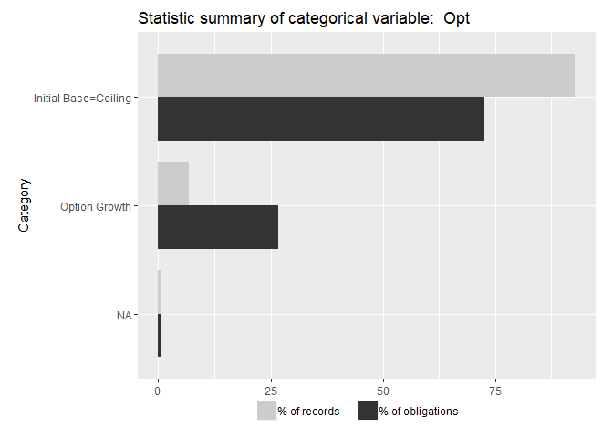

```r
grouped_barplot("Opt", def_serv,value_col="Action_Obligation_Then_Year")
```

```r
statsummary_discrete(c("Opt"), def_serv,value_col="Action_Obligation_Then_Year")
```

```
##                    Opt %of records % of $s
## 1 Initial Base=Ceiling      92.65%  72.65%
## 2        Option Growth       6.82%  26.62%
## 3                   NA       0.54%   0.73%
```

```r
opt<-def_serv %>% filter(b_CBre==1)
opt$qp_OptGrowth<-Hmisc::cut2(opt$p_OptGrowth-1,c(1,10))

highroundedcutoffs<-c(15000,100000,1000000,10000000,75000000)
opt$qHighBase <- Hmisc::cut2(opt$UnmodifiedBase_Then_Year,cuts=highroundedcutoffs)
rm(highroundedcutoffs)#lowroundedcutoffs,


if (all(levels(opt$qHighBase)[1:5]==c("[0.00e+00,1.50e+04)",
                                               "[1.50e+04,1.00e+05)",
                                               "[1.00e+05,1.00e+06)",
                                               "[1.00e+06,1.00e+07)",
                                               "[1.00e+07,7.50e+07)"))|
    all(levels(opt$qHighBase)[1:5]==c("[0.0e+00,1.5e+04)",
                                               "[1.5e+04,1.0e+05)",
                                               "[1.0e+05,1.0e+06)",
                                               "[1.0e+06,1.0e+07)",
                                               "[1.0e+07,7.5e+07)"))
){
  opt$qHighBase<-factor(opt$qHighBase,

                                 levels=levels(opt$qHighBase),
                                 labels=c("[0,15k)",
                                          "[15k,100k)",
                                          "[100k,1m)",
                                          "[1m,10m)",
                                          "[10m,75m)",
                                          "[75m+]"),
                                 ordered=TRUE
  )
}



opt$Why_Outlier<-NA
opt$Why_Outlier[is.na(opt$UnmodifiedBase_Then_Year)]<-"No Unmodified Base"
opt$Why_Outlier[is.na(opt$Why_Outlier)&
                   opt$Action_Obligation_Then_Year*2>=opt$UnmodifiedBase_Then_Year+
                   opt$n_OptGrowth_Then_Year]<-
  "Obligations at least half Base+Opt"
opt$Why_Outlier[is.na(opt$Why_Outlier)&
                   opt$Office=="W912UM"]<-
  "Korean Office W912UM"
opt$Why_Outlier[is.na(opt$Why_Outlier)&
                   opt$n_OptGrowth_Then_Year>=2.5e8]<-
  ">=$250M, Inspect"
opt$Why_Outlier[is.na(opt$Why_Outlier)&
                   opt$p_OptGrowth-1>10]<-
  "Other Unexplained 10x Options Growth"
opt$Why_Outlier<-factor(opt$Why_Outlier,
                         levels=c(
                           "No Unmodified Base",
                           "Obligations at least half Base+Opt",
                           "Later Deobligated",
                           "Korean Office W912UM",
                           ">=$250M, Inspect",
                           "Other Unexplained 10x Options Growth"
                         ))

#Percent Growth
summary(Hmisc::cut2(opt$p_OptGrowth-1,c(1,
                                             10,
                                             100
)))
```

```
## [7.19e-11,1.00e+00) [1.00e+00,1.00e+01) [1.00e+01,1.00e+02)
##               71144                3172                 144
## [1.00e+02,1.31e+04]                NA's
##                  18                 514
```

```r
summary(Hmisc::cut2(opt$p_OptGrowth-1,c(1,
                                    10,
                                    100
)))
```

```
## [7.19e-11,1.00e+00) [1.00e+00,1.00e+01) [1.00e+01,1.00e+02)
##               71144                3172                 144
## [1.00e+02,1.31e+04]                NA's
##                  18                 514
```

```r
summary(opt$qHighBase[(opt$p_OptGrowth-1)>10])
```

```
## [1.00e-02,1.50e+04) [1.50e+04,1.00e+05) [1.00e+05,1.00e+06)
##                  52                  50                  38
## [1.00e+06,1.00e+07) [1.00e+07,7.50e+07) [7.50e+07,1.39e+10]
##                  20                   0                   0
##                NA's
##                 514
```

```r
summary(opt$qHighBase[(opt$p_OptGrowth-1)>100])
```

```
## [1.00e-02,1.50e+04) [1.50e+04,1.00e+05) [1.00e+05,1.00e+06)
##                   8                   4                   4
## [1.00e+06,1.00e+07) [1.00e+07,7.50e+07) [7.50e+07,1.39e+10]
##                   2                   0                   0
##                NA's
##                 514
```

```r
p_outlier_summary<-opt %>% filter(p_OptGrowth-1>10) %>% group_by(Why_Outlier) %>%
  dplyr::summarise(nContract=length(n_OptGrowth_Then_Year),
                   SumOfn_OptGrowth=sum(n_OptGrowth_Then_Year),
                   MaxOfn_OptGrowth=max(n_OptGrowth_Then_Year),
                   SumOfAction_Obligation_Then_Year=sum(Action_Obligation_Then_Year))

#Absolute Growth
summary(Hmisc::cut2(opt$n_OptGrowth_Then_Year,c(1e3,
                                           1e6,
                                           1e7,
                                           1e8,
                                           2.5e8,
                                           1e9,
                                           1e10,
                                           2e10
))
)
```

```
## [1.0e+00,1.0e+03) [1.0e+03,1.0e+06) [1.0e+06,1.0e+07) [1.0e+07,1.0e+08)
##             69967              3314              1357               283
## [1.0e+08,2.5e+08) [2.5e+08,1.0e+09)           1.0e+09 [1.0e+10,2.0e+10]
##                12                 3                 0                 0
##              NA's
##                56
```

```r
summary(Hmisc::cut2(opt$n_OptGrowth_Then_Year,c(1e3,
                                  1e6,
                                  1e7,
                                  1e8,
                                  2.5e8,
                                  1e9,
                                  1e10,
                                  2e10
))
)
```

```
## [1.0e+00,1.0e+03) [1.0e+03,1.0e+06) [1.0e+06,1.0e+07) [1.0e+07,1.0e+08)
##             69967              3314              1357               283
## [1.0e+08,2.5e+08) [2.5e+08,1.0e+09)           1.0e+09 [1.0e+10,2.0e+10]
##                12                 3                 0                 0
##              NA's
##                56
```

```r
summary(opt$qHighBase[opt$n_OptGrowth_Then_Year>=1e6])
```

```
## [1.00e-02,1.50e+04) [1.50e+04,1.00e+05) [1.00e+05,1.00e+06)
##                   7                  23                 491
## [1.00e+06,1.00e+07) [1.00e+07,7.50e+07) [7.50e+07,1.39e+10]
##                 884                 237                   9
##                NA's
##                  60
```

```r
summary(opt$qHighBase[opt$n_OptGrowth_Then_Year>=1e9])
```

```
## [1.00e-02,1.50e+04) [1.50e+04,1.00e+05) [1.00e+05,1.00e+06)
##                   0                   0                   0
## [1.00e+06,1.00e+07) [1.00e+07,7.50e+07) [7.50e+07,1.39e+10]
##                   0                   0                   0
##                NA's
##                  56
```

```r
n_outlier_summary<-opt %>% filter(n_OptGrowth_Then_Year>2.5e8) %>% group_by(Why_Outlier) %>%
  dplyr::summarise(nContract=length(n_OptGrowth_Then_Year),
                   SumOfn_OptGrowth=sum(n_OptGrowth_Then_Year),
                   MaxOfn_OptGrowth=max(n_OptGrowth_Then_Year),
                   SumOfAction_Obligation_Then_Year=sum(Action_Obligation_Then_Year))
```

| Why_Outlier | nContract | SumOfn_OptGrowth | MaxOfn_OptGrowth | SumOfAction_Obligation_Then_Year |
| --- | --- | --- | --- | --- |
| Obligations at least half Base+Opt | 3 | 904202098 | 327123959 | 878601730 |

After the cleaning, 2 categories remain relevant.

| Why_Outlier | nContract | SumOfn_OptGrowth | MaxOfn_OptGrowth | SumOfAction_Obligation_Then_Year |
| --- | --- | --- | --- | --- |
| Obligations at least half Base+Opt | 157 | 2509233057 | 327123959 | 4182321054.8 |
| Other Unexplained 10x Options Growth | 3 | 1277333 | 906044 | 332547.9 |

## 4.1 Graphs after Cleaning

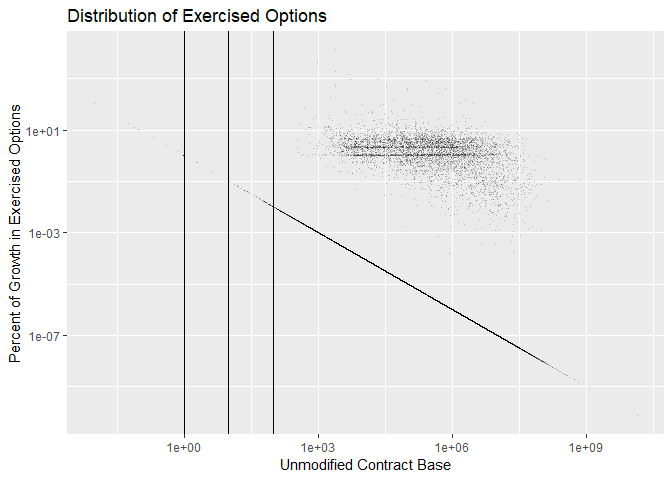

```r
(
  ggplot(opt, aes(x=UnmodifiedBase_Then_Year,y=p_OptGrowth-1)) +#,color=qp_OptGrowth
    geom_point(alpha=0.25,shape=".")+
    # theme(axis.text.x = element_text(angle = 90, hjust = 1))+
    scale_x_log10()+scale_y_log10()+
    #+
    geom_vline(xintercept = c(1,10,100))+#+geom_vline(xintercept = 0.1)+
    # facet_wrap(~qHighBase,scales="free_y")+#+, space="free_y"
    labs(title="Distribution of Exercised Options",
         y="Percent of Growth in Exercised Options",
         x="Unmodified Contract Base")#,
  # fill="Termination Completion"
)
```

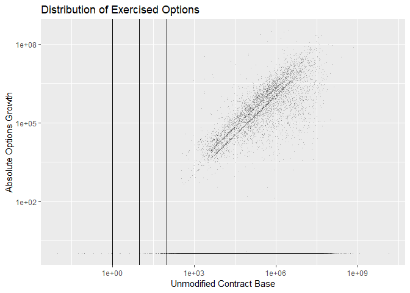

```r
(
  ggplot(opt, aes(x=UnmodifiedBase_Then_Year,y=n_OptGrowth_Then_Year)) +#,color=qp_OptGrowth
    geom_point(alpha=0.25,shape=".")+
    # theme(axis.text.x = element_text(angle = 90, hjust = 1))+
    scale_x_log10()+scale_y_log10()+
    #+
    geom_vline(xintercept = c(1,10,100))+#+geom_vline(xintercept = 0.1)+
    # facet_wrap(~qHighBase,scales="free_y")+#+, space="free_y"
    labs(title="Distribution of Exercised Options",
         y="Absolute Options Growth",
         x="Unmodified Contract Base")#,
  # fill="Termination Completion"
)
```

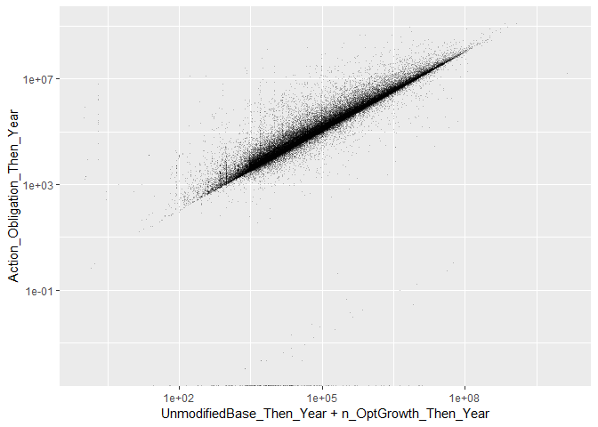

```r
(
  ggplot(opt, aes(x=UnmodifiedBase_Then_Year+n_OptGrowth_Then_Year,
                   y=Action_Obligation_Then_Year)) +#,color=qp_OptGrowth
    geom_point(alpha=0.25,shape=".")+
    # theme(axis.text.x = element_text(angle = 90, hjust = 1))+
    scale_x_log10()+scale_y_log10()#+
  #+
  #   geom_vline(xintercept = c(1,10,100))+#+geom_vline(xintercept = 0.1)+
  # # facet_wrap(~qHighBase,scales="free_y")+#+, space="free_y"
  #   labs(title="Distribution of Exercised Options",
  #        y="Percent of Growth in Exercised Options",
  #        x="Unmodified Contract Base")#,
  #        # fill="Termination Completion"
)
```

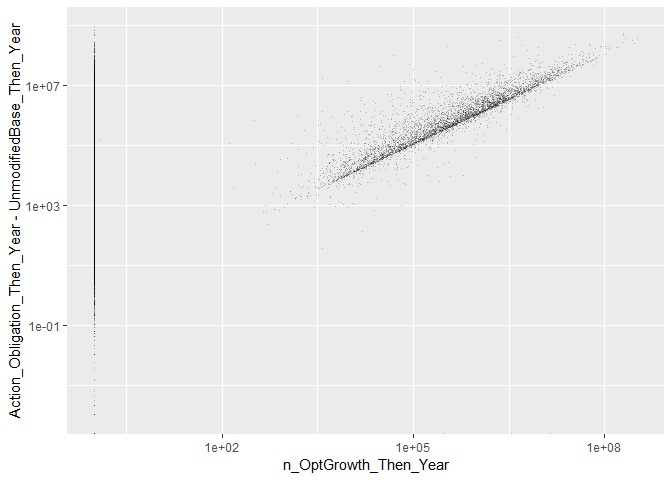

```r
(
  ggplot(opt, aes(x=n_OptGrowth_Then_Year,
                   y=Action_Obligation_Then_Year-UnmodifiedBase_Then_Year)) +#,color=qp_OptGrowth
    geom_point(alpha=0.25,shape=".")+
    # theme(axis.text.x = element_text(angle = 90, hjust = 1))+
    scale_x_log10()+scale_y_log10()#+
  #+
  #   geom_vline(xintercept = c(1,10,100))+#+geom_vline(xintercept = 0.1)+
  # # facet_wrap(~qHighBase,scales="free_y")+#+, space="free_y"
  #   labs(title="Distribution of Exercised Options",
  #        y="Percent of Growth in Exercised Options",
  #        x="Unmodified Contract Base")#,
  #        # fill="Termination Completion"
)
```

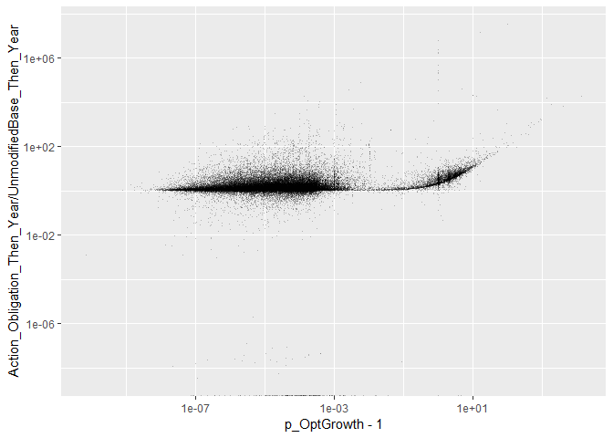

```r
#
(
  ggplot(opt, aes(x=p_OptGrowth-1,
                   y=Action_Obligation_Then_Year/UnmodifiedBase_Then_Year)) +#,color=qp_OptGrowth
    geom_point(alpha=0.25,shape=".")+
    # theme(axis.text.x = element_text(angle = 90, hjust = 1))+
    scale_x_log10()+scale_y_log10()#+
  #+
  #   geom_vline(xintercept = c(1,10,100))+#+geom_vline(xintercept = 0.1)+
  # # facet_wrap(~qHighBase,scales="free_y")+#+, space="free_y"
  #   labs(title="Distribution of Exercised Options",
  #        y="Percent of Growth in Exercised Options",
  #        x="Unmodified Contract Base")#,
  #        # fill="Termination Completion"
)
```

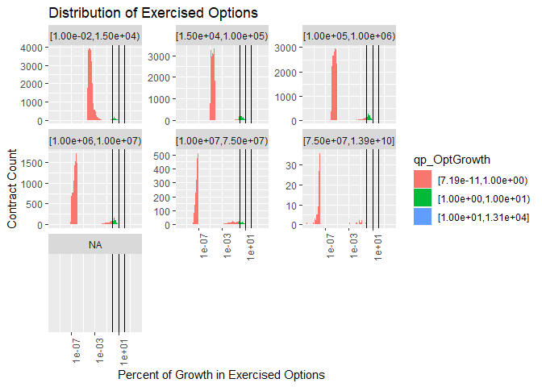

```r
(
  ggplot(opt, aes(x=p_OptGrowth-1,fill=qp_OptGrowth)) +
    geom_histogram(bins=100)+
    theme(axis.text.x = element_text(angle = 90, hjust = 1))+
    scale_x_log10()+
    #+
    geom_vline(xintercept = c(1,10,100))+#+geom_vline(xintercept = 0.1)+
    facet_wrap(~qHighBase,scales="free_y")+#+, space="free_y"
    labs(title="Distribution of Exercised Options",
         y="Contract Count",
         x="Percent of Growth in Exercised Options")#,
  # fill="Termination Completion"
)
```

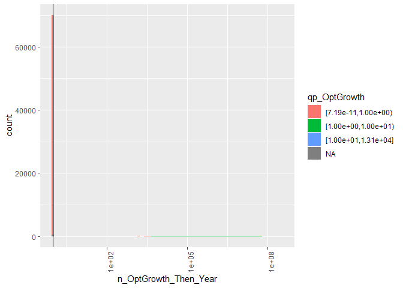

```r
(
  ggplot(opt, aes(x=n_OptGrowth_Then_Year,fill=qp_OptGrowth)) +
    geom_histogram(bins=100)+
    theme(axis.text.x = element_text(angle = 90, hjust = 1))+
    scale_x_log10()+
    #+
    geom_vline(xintercept = 1)#+geom_vline(xintercept = 0.1)+
  #facet_grid(NoPreTermObl~.,scales="free_y", space="free_y")+
  # labs(title="Distribution of Contracts with Obligations After Last termination",
  #      y="Contract Count",
  #      x="Percent of Obligations After Day of Termination",
  #      fill="Termination Completion"
)
```

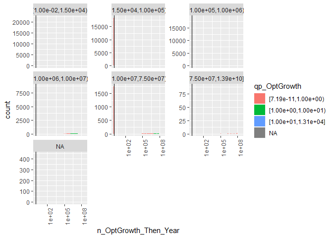

```r
(
  ggplot(opt, aes(x=n_OptGrowth_Then_Year,fill=qp_OptGrowth)) +
    geom_histogram(bins=100)+
    theme(axis.text.x = element_text(angle = 90, hjust = 1))+
    scale_x_log10()+
    #+
    geom_vline(xintercept = 1)+
    facet_wrap(~qHighBase,scales="free_y")#+, space="free_y"
  #+geom_vline(xintercept = 0.1)+
  #facet_grid(NoPreTermObl~.,scales="free_y", space="free_y")+
  # labs(title="Distribution of Contracts with Obligations After Last termination",
  #      y="Contract Count",
  #      x="Percent of Obligations After Day of Termination",
  #      fill="Termination Completion"
)
```

# 5 Proportion of Options Exercised

```r
if(file.exists("..\\data\\semi_clean\\serv_opt.rdata")){
  load("..\\data\\semi_clean\\serv_opt.rdata")
} else {
  serv_opt<-csis360::standardize_variable_names(serv_opt)
  dupe_psa<-which(colnames(serv_opt)=="ProductOrServiceArea")
  if(length(dupe_psa)>1)
    serv_opt<-serv_opt[,-c(dupe_psa[2:length(dupe_psa)])]
  colnames(serv_opt)[colnames(serv_opt)=="UnmodifiedCeiling_Then_Year"]<-"UnmodifiedCeiling"

  #Ceiling Variables
  serv_opt<-input_contract_ceiling_breach(serv_opt,
                                          file="Contract.SP_ContractCeilingBreachCustomer.txt")
  colnames(serv_opt)[colnames(serv_opt)=="UnmodifiedCeiling"]<-"UnmodifiedCeiling_Then_Year"

#Base Variables
  serv_opt<-read_and_join_experiment( serv_opt  ,
                                        "Contract.sp_ContractExercisedOptions.txt",
                                        path="",
                                        directory="..\\data\\semi_clean\\",
                                        by=c("CSIScontractID"),
                                        # add_var=c("AnyUnmodifiedUnexercisedOptions",
                                        #           "AnyUnmodifiedUnexercisedOptionsWhy",
                                        #           "UnmodifiedBase",
                                        #           "SteadyScopeOptionGrowthAlone",
                                        #           "SteadyScopeOptionRescision",
                                        #           "AdminOptionModification"),
                                        new_var_checked=FALSE,
                                        create_lookup_rdata=TRUE,
                                        lookup_char_as_factor=TRUE)



  colnames(serv_opt)[colnames(serv_opt)=="UnmodifiedBase"]<-"UnmodifiedBase_Then_Year"
    colnames(serv_opt)[colnames(serv_opt)=="n_OptGrowth"]<-"n_OptGrowth_Then_Year"




}
```

```r
#Determine original and updated space available
serv_opt$OptSpaceOriginal<-serv_opt$UnmodifiedCeiling_Then_Year-serv_opt$UnmodifiedBase_Then_Year
summary(serv_opt$OptSpaceOriginal)
```

```
##      Min.   1st Qu.    Median      Mean   3rd Qu.      Max.
## 0.000e+00 2.697e+04 9.999e+04 2.063e+07 5.885e+05 7.255e+10
```

```r
serv_opt$OptSpaceUpdated<-serv_opt$UnmodifiedCeiling_Then_Year+serv_opt$ChangeOrderCeilingGrowth+
  serv_opt$AdminCeilingModification+serv_opt$SteadyScopeCeilingModification+serv_opt$OtherCeilingModification-
  serv_opt$UnmodifiedBase_Then_Year
summary(serv_opt$OptSpaceUpdated)
```

```
##       Min.    1st Qu.     Median       Mean    3rd Qu.       Max.
## -4.990e+07  2.585e+04  1.041e+05  2.110e+07  6.499e+05  7.255e+10
```

```r
#Not included in the update ceiling.
#ChangeOrderCeilingRescision
#EndingCeilingModification+
#OtherCeilingModification+
summary(serv_opt$Opt)
```

```
## Initial Base=Ceiling        Option Growth
##                    0                74274
```

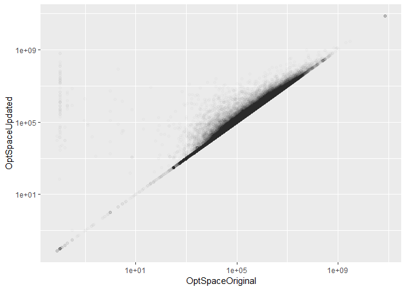

```r
# colnames(serv_opt)[duplicated(colnames(serv_opt))]
# serv_opt<-serv_opt[,-which(duplicated(colnames(serv_opt)))]
# which(duplicated(colnames(serv_opt)))
serv_opt$OptSpaceUpdated[serv_opt$OptSpaceOriginal>serv_opt$OptSpaceUpdated] <-
  serv_opt$OptSpaceOriginal[serv_opt$OptSpaceOriginal>serv_opt$OptSpaceUpdated]

if(any(colnames(serv_opt)[duplicated(colnames(serv_opt))])) stop("duplicte column names")
#This only works if there's just one duplicated name.
# dupe<-which(colnames(serv_opt) %in% colnames(serv_opt)[duplicated(colnames(serv_opt))])
# serv_opt<-serv_opt[,-c(dupe[2:length(dupe)])]

ggplot(serv_opt,aes(x=OptSpaceOriginal,y=OptSpaceUpdated))+geom_point(alpha=0.01)+scale_x_log10()+scale_y_log10()
```

```r
#Proportion of options
serv_opt$ExerOriginal<-(serv_opt$n_OptGrowth_Then_Year-1)/serv_opt$OptSpaceOriginal
serv_opt$ExerOriginal[serv_opt$ExerOriginal>1]<-1
summary(serv_opt$ExerOriginal)
```

```
##    Min. 1st Qu.  Median    Mean 3rd Qu.    Max.
##  0.0000  0.0000  0.3443  0.4325  0.9675  1.0000
```

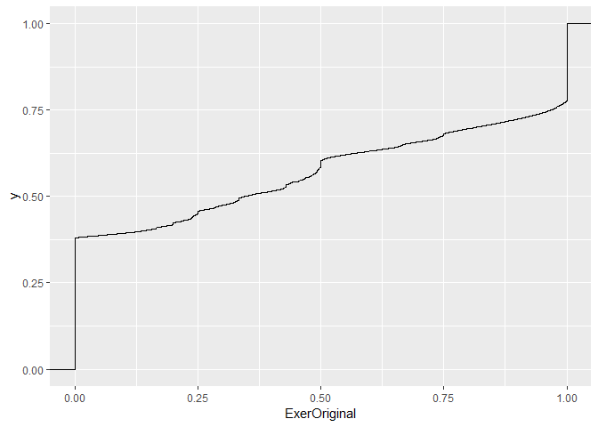

```r
ggplot(serv_opt, aes(x=ExerOriginal)) + stat_ecdf(geom = "step")
```

```r
serv_opt$ExerUpdate<-(serv_opt$ChangeOrderOptionModification+
                        serv_opt$SteadyScopeOptionGrowthAlone+
                        serv_opt$SteadyScopeOptionGrowthMixed+
                        serv_opt$SteadyScopeOptionRescision+
                        serv_opt$AdminOptionModification+
                        serv_opt$OtherOptionModification
                      )/serv_opt$OptSpaceUpdated
serv_opt$ExerUpdate[serv_opt$ExerUpdate>1]<-1
serv_opt$ExerUpdate[serv_opt$ExerUpdate<0]<-0
summary(serv_opt$ExerUpdate)
```

```
##    Min. 1st Qu.  Median    Mean 3rd Qu.    Max.
##  0.0000  0.0000  0.5096  0.5314  1.0000  1.0000
```

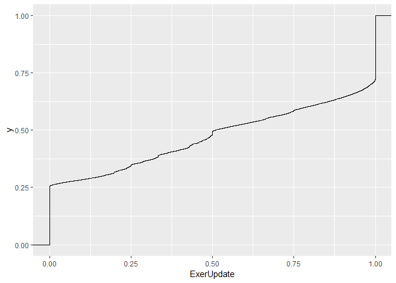

```r
ggplot(serv_opt, aes(x=ExerUpdate)) + stat_ecdf(geom = "step")
```

```r
#Excludes serv_opt$EndingOptionModification+

serv_opt$Exer<-ifelse(serv_opt$ExerUpdate>serv_opt$ExerOriginal,serv_opt$ExerUpdate,serv_opt$ExerOriginal)
summary(serv_opt$Exer)
```

```
##    Min. 1st Qu.  Median    Mean 3rd Qu.    Max.
##  0.0000  0.0000  0.5229  0.5378  1.0000  1.0000
```

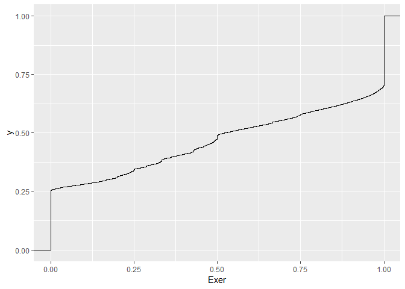

```r
ggplot(serv_opt, aes(x=Exer)) + stat_ecdf(geom = "step")
```

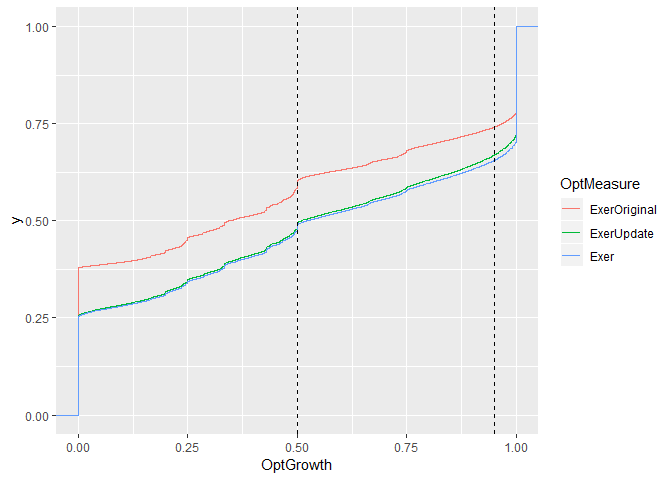

```r
serv_opt_long<-tidyr::gather(serv_opt,OptMeasure,OptGrowth,c(ExerOriginal,ExerUpdate,Exer),factor_key=TRUE)
ggplot(serv_opt_long, aes(x=OptGrowth,color=OptMeasure)) + stat_ecdf(geom = "step")+
  geom_vline(xintercept =c(0.5,0.95),linetype=2)#,0.975
```

```r
nrow(serv_opt[serv_opt$Exer<=0.000001,])
```

```
## [1] 18853
```

```r
nrow(serv_opt[serv_opt$n_OptGrowth_Then_Year==0,])
```

```
## [1] 0
```

Of the two different measures, strictly defined option growth over the original gap between base and ceiling is clearly the more conservative. The first way of measuring outcomes is to allow either measure for reaching All, but only the stricter measure of growth for reaching some.

The choice to set the maximum threshold at above 0.95 rather than simply 100% is driven by the upward curve near the end of the cumulative distribution function. Because those contracts do appear to stand apart, rounding up seems a reasonable step. Similar approaches are taken for other variables, primarily pricing, where a contract that has the vast majority of obligations under one particular type can still qualify with the cut off for vast majority at that final uptick point.

```r
serv_opt$b_AllOpt<-ifelse(serv_opt$Exer>0.95,1,0)
summary(serv_opt$b_AllOpt)
```

```
##    Min. 1st Qu.  Median    Mean 3rd Qu.    Max.
##  0.0000  0.0000  0.0000  0.3444  1.0000  1.0000
```

```r
serv_opt$b_SomeOpt_Strict<-ifelse(serv_opt$n_OptGrowth_Then_Year>1,1,0)
summary(serv_opt$b_SomeOpt_Strict)
```

```
##    Min. 1st Qu.  Median    Mean 3rd Qu.    Max.
##  0.0000  0.0000  1.0000  0.6204  1.0000  1.0000
```

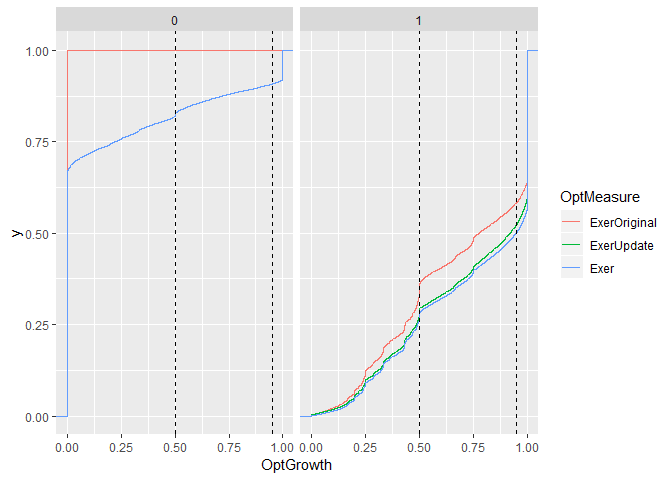

```r
serv_opt_long<-tidyr::gather(serv_opt,OptMeasure,OptGrowth,c(ExerOriginal,ExerUpdate,Exer),factor_key=TRUE)
ggplot(serv_opt_long, aes(x=OptGrowth,color=OptMeasure)) + stat_ecdf(geom = "step")+
  geom_vline(xintercept =c(0.5,0.95),linetype=2)+facet_wrap(~b_SomeOpt_Strict)
```

```r
serv_opt$CeilGrowth<-serv_opt$OptSpaceUpdated-serv_opt$OptSpaceOriginal
serv_opt$b_SomeOpt<-serv_opt$b_SomeOpt_Strict
serv_opt$b_SomeOpt[serv_opt$ChangeOrderOptionModification+
                        serv_opt$SteadyScopeOptionGrowthAlone+
                        serv_opt$SteadyScopeOptionGrowthMixed+
                        serv_opt$SteadyScopeOptionRescision+
                        serv_opt$AdminOptionModification+
                        serv_opt$OtherOptionModification>serv_opt$CeilGrowth]<-1
summary(serv_opt$b_SomeOpt)
```

```
##    Min. 1st Qu.  Median    Mean 3rd Qu.    Max.
##  0.0000  0.0000  1.0000  0.6915  1.0000  1.0000
```

```r
summary(serv_opt$b_SomeOpt_Strict)
```

```
##    Min. 1st Qu.  Median    Mean 3rd Qu.    Max.
##  0.0000  0.0000  1.0000  0.6204  1.0000  1.0000
```

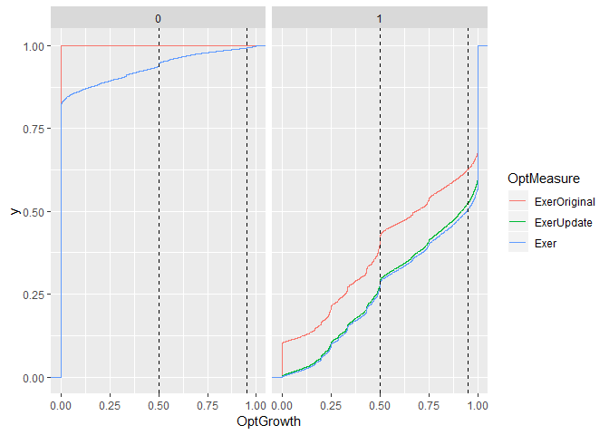

```r
serv_opt_long<-tidyr::gather(serv_opt,OptMeasure,OptGrowth,c(ExerOriginal,ExerUpdate,Exer),factor_key=TRUE)
ggplot(serv_opt_long, aes(x=OptGrowth,color=OptMeasure)) + stat_ecdf(geom = "step")+
  geom_vline(xintercept =c(0.5,0.95),linetype=2)+facet_wrap(~b_SomeOpt)
```

```r
if(any(serv_opt$b_SomeOpt==0 & serv_opt$Exer>=1))
   stop("Somehow a contract that does not meet the some criteria has reach 100% exercised.")
serv_opt$b_AllOpt[serv_opt$b_SomeOpt==0]<-0
```

There is now only a tiny minority of contracts (0.0023157) that meet the criteria for all options exercised without meeting the criteria for some exercised. These contracts are set as not qualify for the all criteria despite having 95% growth.

```r
serv_opt<-transition_variable_names_service(serv_opt)
serv_exeropt<-dplyr::filter(serv_opt,b_SomeOpt==1)
save(serv_opt,serv_exeropt,file="..\\data\\semi_clean\\serv_opt.rdata")
```